# Optimal Treatment Analysis

## Outcome Variable

**Outcome Variable:** ever_wasted

## Predictor Variables

**Intervention Variable:** nhh

**Adjustment Set:**

- arm
- W_mage
- meducyrs
- feducyrs
- hhwealth_quart
- W_mhtcm
- W_mwtkg
- W_mbmi
- W_nrooms
- cleanck
- impfloor
- impsan
- safeh20
- delta_W_mage
- delta_meducyrs
- delta_feducyrs
- delta_hhwealth_quart
- delta_W_mhtcm
- delta_W_mwtkg
- delta_W_mbmi
- delta_W_nrooms
- delta_cleanck
- delta_impfloor
- delta_impsan
- delta_safeh20

## Stratifying Variables

The analysis was stratified on these variable(s):

- agecat
- studyid
- country

## Data Summary

| agecat | studyid | country | nhh | ever_wasted | n_cell | n |
| --- | --- | --- | --- | --- | --- | --- |
| 0-24 months | ki1000108-IRC | INDIA | 3 or less | 0 | 20 | 410 |
| 0-24 months | ki1000108-IRC | INDIA | 3 or less | 1 | 38 | 410 |
| 0-24 months | ki1000108-IRC | INDIA | 4-5 | 0 | 63 | 410 |
| 0-24 months | ki1000108-IRC | INDIA | 4-5 | 1 | 95 | 410 |
| 0-24 months | ki1000108-IRC | INDIA | 6-7 | 0 | 38 | 410 |
| 0-24 months | ki1000108-IRC | INDIA | 6-7 | 1 | 69 | 410 |
| 0-24 months | ki1000108-IRC | INDIA | 8+ | 0 | 20 | 410 |
| 0-24 months | ki1000108-IRC | INDIA | 8+ | 1 | 67 | 410 |
| 0-24 months | ki1000304b-SAS-FoodSuppl | INDIA | 3 or less | 0 | 4 | 106 |
| 0-24 months | ki1000304b-SAS-FoodSuppl | INDIA | 3 or less | 1 | 5 | 106 |
| 0-24 months | ki1000304b-SAS-FoodSuppl | INDIA | 4-5 | 0 | 19 | 106 |
| 0-24 months | ki1000304b-SAS-FoodSuppl | INDIA | 4-5 | 1 | 22 | 106 |
| 0-24 months | ki1000304b-SAS-FoodSuppl | INDIA | 6-7 | 0 | 20 | 106 |
| 0-24 months | ki1000304b-SAS-FoodSuppl | INDIA | 6-7 | 1 | 17 | 106 |
| 0-24 months | ki1000304b-SAS-FoodSuppl | INDIA | 8+ | 0 | 10 | 106 |
| 0-24 months | ki1000304b-SAS-FoodSuppl | INDIA | 8+ | 1 | 9 | 106 |
| 0-24 months | ki1017093-NIH-Birth | BANGLADESH | 3 or less | 0 | 58 | 624 |
| 0-24 months | ki1017093-NIH-Birth | BANGLADESH | 3 or less | 1 | 57 | 624 |
| 0-24 months | ki1017093-NIH-Birth | BANGLADESH | 4-5 | 0 | 134 | 624 |
| 0-24 months | ki1017093-NIH-Birth | BANGLADESH | 4-5 | 1 | 129 | 624 |
| 0-24 months | ki1017093-NIH-Birth | BANGLADESH | 6-7 | 0 | 72 | 624 |
| 0-24 months | ki1017093-NIH-Birth | BANGLADESH | 6-7 | 1 | 69 | 624 |
| 0-24 months | ki1017093-NIH-Birth | BANGLADESH | 8+ | 0 | 62 | 624 |
| 0-24 months | ki1017093-NIH-Birth | BANGLADESH | 8+ | 1 | 43 | 624 |
| 0-24 months | ki1017093b-PROVIDE | BANGLADESH | 3 or less | 0 | 98 | 700 |
| 0-24 months | ki1017093b-PROVIDE | BANGLADESH | 3 or less | 1 | 42 | 700 |
| 0-24 months | ki1017093b-PROVIDE | BANGLADESH | 4-5 | 0 | 211 | 700 |
| 0-24 months | ki1017093b-PROVIDE | BANGLADESH | 4-5 | 1 | 111 | 700 |
| 0-24 months | ki1017093b-PROVIDE | BANGLADESH | 6-7 | 0 | 94 | 700 |
| 0-24 months | ki1017093b-PROVIDE | BANGLADESH | 6-7 | 1 | 57 | 700 |

[output cut: 114 more lines]

The following strata were considered:

- agecat: 0-24 months, studyid: ki1000108-IRC, country: INDIA
- agecat: 0-24 months, studyid: ki1000304b-SAS-FoodSuppl, country: INDIA
- agecat: 0-24 months, studyid: ki1017093-NIH-Birth, country: BANGLADESH
- agecat: 0-24 months, studyid: ki1017093b-PROVIDE, country: BANGLADESH
- agecat: 0-24 months, studyid: ki1017093c-NIH-Crypto, country: BANGLADESH
- agecat: 0-24 months, studyid: ki1148112-LCNI-5, country: MALAWI
- agecat: 0-6 months, studyid: ki1000108-IRC, country: INDIA
- agecat: 0-6 months, studyid: ki1000304b-SAS-FoodSuppl, country: INDIA
- agecat: 0-6 months, studyid: ki1017093-NIH-Birth, country: BANGLADESH
- agecat: 0-6 months, studyid: ki1017093b-PROVIDE, country: BANGLADESH
- agecat: 0-6 months, studyid: ki1017093c-NIH-Crypto, country: BANGLADESH
- agecat: 0-6 months, studyid: ki1148112-LCNI-5, country: MALAWI
- agecat: 6-24 months, studyid: ki1000108-IRC, country: INDIA
- agecat: 6-24 months, studyid: ki1000304b-SAS-FoodSuppl, country: INDIA
- agecat: 6-24 months, studyid: ki1017093-NIH-Birth, country: BANGLADESH
- agecat: 6-24 months, studyid: ki1017093b-PROVIDE, country: BANGLADESH
- agecat: 6-24 months, studyid: ki1017093c-NIH-Crypto, country: BANGLADESH
- agecat: 6-24 months, studyid: ki1148112-LCNI-5, country: MALAWI

### Dropped Strata

Some strata were dropped due to rare outcomes:

- agecat: 0-24 months, studyid: ki1000304b-SAS-FoodSuppl, country: INDIA
- agecat: 0-6 months, studyid: ki1000304b-SAS-FoodSuppl, country: INDIA
- agecat: 0-6 months, studyid: ki1148112-LCNI-5, country: MALAWI
- agecat: 6-24 months, studyid: ki1000304b-SAS-FoodSuppl, country: INDIA

## Methods Detail

We’re interested in the causal parameters $E[Y_a]$ for all values of $a \in \mathcal{A}$. These parameters represent the mean outcome if, possibly contrary to fact, we intervened to set all units to have $A=a$. Under the randomization and positivity assumptions, these are identified by the statistical parameters $\psi_a=E_W[E_{Y|A,W}(Y|A=a,W)]$. In addition, we’re interested in the mean of $Y$, $E[Y]$ under no intervention (the observed mean). We will estimate these parameters by using SuperLearner to fit the relevant likelihood factors – $E_{Y|A,W}(Y|A=a,W)$ and $p(A=a|W)$, and then updating our likelihood fit using a joint TMLE.

For unadjusted analyses ($W=\{\}$), initial likelihoods were estimated using Lrnr_glm to estimate the simple $E(Y|A)$ and Lrnr_mean to estimate $p(A)$. For adjusted analyses, a small library containing Lrnr_glmnet, Lrnr_xgboost, and Lrnr_mean was used.

Having estimated these parameters, we will then use the delta method to estimate relative risks and attributable risks relative to a prespecified baseline level of $A$.

# Results Detail

## Results Plots

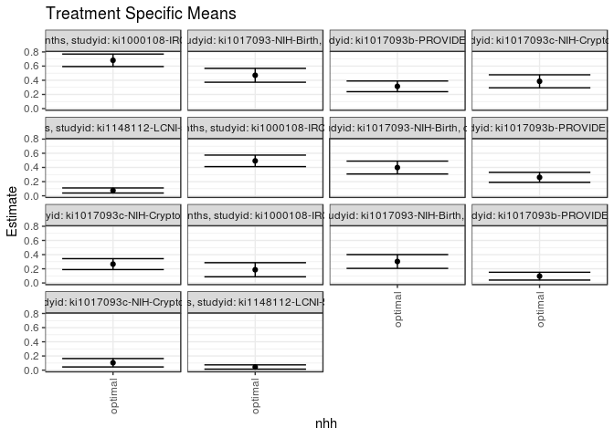

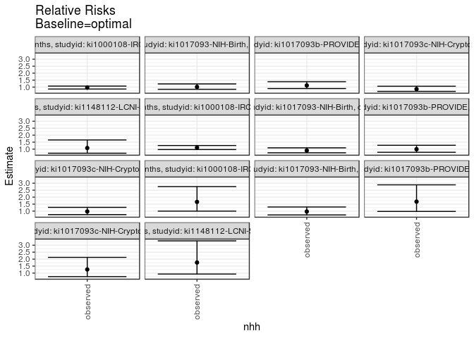

## Results Table

### Parameter: TSM

| agecat | studyid | country | intervention_level | baseline_level | estimate | ci_lower | ci_upper |
| --- | --- | --- | --- | --- | --- | --- | --- |
| 0-24 months | ki1000108-IRC | INDIA | optimal | NA | 0.6817010 | 0.5935044 | 0.7698977 |
| 0-24 months | ki1017093-NIH-Birth | BANGLADESH | optimal | NA | 0.4700972 | 0.3725095 | 0.5676849 |
| 0-24 months | ki1017093b-PROVIDE | BANGLADESH | optimal | NA | 0.3142587 | 0.2389031 | 0.3896144 |
| 0-24 months | ki1017093c-NIH-Crypto | BANGLADESH | optimal | NA | 0.3852900 | 0.2932669 | 0.4773132 |
| 0-24 months | ki1148112-LCNI-5 | MALAWI | optimal | NA | 0.0748225 | 0.0388536 | 0.1107914 |
| 0-6 months | ki1000108-IRC | INDIA | optimal | NA | 0.4927801 | 0.4114972 | 0.5740629 |
| 0-6 months | ki1017093-NIH-Birth | BANGLADESH | optimal | NA | 0.3984903 | 0.3077252 | 0.4892554 |
| 0-6 months | ki1017093b-PROVIDE | BANGLADESH | optimal | NA | 0.2604332 | 0.1900266 | 0.3308399 |
| 0-6 months | ki1017093c-NIH-Crypto | BANGLADESH | optimal | NA | 0.2658256 | 0.1887742 | 0.3428769 |
| 6-24 months | ki1000108-IRC | INDIA | optimal | NA | 0.1866551 | 0.0871124 | 0.2861978 |
| 6-24 months | ki1017093-NIH-Birth | BANGLADESH | optimal | NA | 0.3034030 | 0.2063130 | 0.4004929 |
| 6-24 months | ki1017093b-PROVIDE | BANGLADESH | optimal | NA | 0.0958898 | 0.0406649 | 0.1511147 |
| 6-24 months | ki1017093c-NIH-Crypto | BANGLADESH | optimal | NA | 0.1043379 | 0.0450600 | 0.1636158 |
| 6-24 months | ki1148112-LCNI-5 | MALAWI | optimal | NA | 0.0445077 | 0.0142477 | 0.0747677 |

### Parameter: E(Y)

| agecat | studyid | country | intervention_level | baseline_level | estimate | ci_lower | ci_upper |
| --- | --- | --- | --- | --- | --- | --- | --- |
| 0-24 months | ki1000108-IRC | INDIA | observed | NA | 0.6560976 | 0.6100625 | 0.7021326 |
| 0-24 months | ki1017093-NIH-Birth | BANGLADESH | observed | NA | 0.4775641 | 0.4383415 | 0.5167867 |
| 0-24 months | ki1017093b-PROVIDE | BANGLADESH | observed | NA | 0.3514286 | 0.3160364 | 0.3868207 |
| 0-24 months | ki1017093c-NIH-Crypto | BANGLADESH | observed | NA | 0.3311346 | 0.2976093 | 0.3646598 |
| 0-24 months | ki1148112-LCNI-5 | MALAWI | observed | NA | 0.0807834 | 0.0620863 | 0.0994804 |
| 0-6 months | ki1000108-IRC | INDIA | observed | NA | 0.5439024 | 0.4956326 | 0.5921723 |
| 0-6 months | ki1017093-NIH-Birth | BANGLADESH | observed | NA | 0.3569132 | 0.3192325 | 0.3945938 |
| 0-6 months | ki1017093b-PROVIDE | BANGLADESH | observed | NA | 0.2585714 | 0.2261125 | 0.2910304 |
| 0-6 months | ki1017093c-NIH-Crypto | BANGLADESH | observed | NA | 0.2585752 | 0.2273844 | 0.2897660 |
| 6-24 months | ki1000108-IRC | INDIA | observed | NA | 0.3097561 | 0.2649438 | 0.3545684 |
| 6-24 months | ki1017093-NIH-Birth | BANGLADESH | observed | NA | 0.2939002 | 0.2554778 | 0.3323226 |
| 6-24 months | ki1017093b-PROVIDE | BANGLADESH | observed | NA | 0.1609756 | 0.1319065 | 0.1900447 |
| 6-24 months | ki1017093c-NIH-Crypto | BANGLADESH | observed | NA | 0.1315068 | 0.1069744 | 0.1560393 |
| 6-24 months | ki1148112-LCNI-5 | MALAWI | observed | NA | 0.0782609 | 0.0596958 | 0.0968259 |

### Parameter: RR

| agecat | studyid | country | intervention_level | baseline_level | estimate | ci_lower | ci_upper |
| --- | --- | --- | --- | --- | --- | --- | --- |
| 0-24 months | ki1000108-IRC | INDIA | observed | optimal | 0.9624418 | 0.8628760 | 1.073496 |
| 0-24 months | ki1017093-NIH-Birth | BANGLADESH | observed | optimal | 1.0158837 | 0.8409398 | 1.227222 |
| 0-24 months | ki1017093b-PROVIDE | BANGLADESH | observed | optimal | 1.1182778 | 0.9012232 | 1.387609 |
| 0-24 months | ki1017093c-NIH-Crypto | BANGLADESH | observed | optimal | 0.8594424 | 0.6943305 | 1.063818 |
| 0-24 months | ki1148112-LCNI-5 | MALAWI | observed | optimal | 1.0796667 | 0.7039240 | 1.655974 |
| 0-6 months | ki1000108-IRC | INDIA | observed | optimal | 1.1037427 | 0.9684601 | 1.257923 |
| 0-6 months | ki1017093-NIH-Birth | BANGLADESH | observed | optimal | 0.8956635 | 0.7348745 | 1.091633 |
| 0-6 months | ki1017093b-PROVIDE | BANGLADESH | observed | optimal | 0.9928512 | 0.7726312 | 1.275840 |
| 0-6 months | ki1017093c-NIH-Crypto | BANGLADESH | observed | optimal | 0.9727251 | 0.7461415 | 1.268116 |
| 6-24 months | ki1000108-IRC | INDIA | observed | optimal | 1.6595104 | 0.9982368 | 2.758839 |
| 6-24 months | ki1017093-NIH-Birth | BANGLADESH | observed | optimal | 0.9686794 | 0.7247915 | 1.294634 |
| 6-24 months | ki1017093b-PROVIDE | BANGLADESH | observed | optimal | 1.6787566 | 0.9776523 | 2.882644 |
| 6-24 months | ki1017093c-NIH-Crypto | BANGLADESH | observed | optimal | 1.2603938 | 0.7469399 | 2.126801 |
| 6-24 months | ki1148112-LCNI-5 | MALAWI | observed | optimal | 1.7583668 | 0.9330852 | 3.313582 |

### Parameter: PAR

| agecat | studyid | country | intervention_level | baseline_level | estimate | ci_lower | ci_upper |
| --- | --- | --- | --- | --- | --- | --- | --- |
| 0-24 months | ki1000108-IRC | INDIA | optimal | NA | -0.0256035 | -0.1000558 | 0.0488488 |
| 0-24 months | ki1017093-NIH-Birth | BANGLADESH | optimal | NA | 0.0074669 | -0.0813684 | 0.0963022 |
| 0-24 months | ki1017093b-PROVIDE | BANGLADESH | optimal | NA | 0.0371698 | -0.0306800 | 0.1050197 |
| 0-24 months | ki1017093c-NIH-Crypto | BANGLADESH | optimal | NA | -0.0541554 | -0.1366965 | 0.0283856 |
| 0-24 months | ki1148112-LCNI-5 | MALAWI | optimal | NA | 0.0059609 | -0.0261110 | 0.0380327 |
| 0-6 months | ki1000108-IRC | INDIA | optimal | NA | 0.0511223 | -0.0130333 | 0.1152780 |
| 0-6 months | ki1017093-NIH-Birth | BANGLADESH | optimal | NA | -0.0415771 | -0.1207125 | 0.0375583 |
| 0-6 months | ki1017093b-PROVIDE | BANGLADESH | optimal | NA | -0.0018618 | -0.0671527 | 0.0634292 |
| 0-6 months | ki1017093c-NIH-Crypto | BANGLADESH | optimal | NA | -0.0072504 | -0.0777374 | 0.0632366 |
| 6-24 months | ki1000108-IRC | INDIA | optimal | NA | 0.1231010 | 0.0271810 | 0.2190210 |
| 6-24 months | ki1017093-NIH-Birth | BANGLADESH | optimal | NA | -0.0095028 | -0.0975328 | 0.0785273 |
| 6-24 months | ki1017093b-PROVIDE | BANGLADESH | optimal | NA | 0.0650858 | 0.0123258 | 0.1178459 |
| 6-24 months | ki1017093c-NIH-Crypto | BANGLADESH | optimal | NA | 0.0271689 | -0.0272854 | 0.0816233 |
| 6-24 months | ki1148112-LCNI-5 | MALAWI | optimal | NA | 0.0337532 | 0.0045510 | 0.0629553 |

### Parameter: PAF

| agecat | studyid | country | intervention_level | baseline_level | estimate | ci_lower | ci_upper |
| --- | --- | --- | --- | --- | --- | --- | --- |
| 0-24 months | ki1000108-IRC | INDIA | optimal | NA | -0.0390239 | -0.1589151 | 0.0684644 |
| 0-24 months | ki1017093-NIH-Birth | BANGLADESH | optimal | NA | 0.0156354 | -0.1891458 | 0.1851514 |
| 0-24 months | ki1017093b-PROVIDE | BANGLADESH | optimal | NA | 0.1057678 | -0.1096030 | 0.2793357 |
| 0-24 months | ki1017093c-NIH-Crypto | BANGLADESH | optimal | NA | -0.1635451 | -0.4402364 | 0.0599895 |
| 0-24 months | ki1148112-LCNI-5 | MALAWI | optimal | NA | 0.0737882 | -0.4206079 | 0.3961259 |
| 0-6 months | ki1000108-IRC | INDIA | optimal | NA | 0.0939918 | -0.0325670 | 0.2050386 |
| 0-6 months | ki1017093-NIH-Birth | BANGLADESH | optimal | NA | -0.1164908 | -0.3607766 | 0.0839410 |
| 0-6 months | ki1017093b-PROVIDE | BANGLADESH | optimal | NA | -0.0072003 | -0.2942786 | 0.2162024 |
| 0-6 months | ki1017093c-NIH-Crypto | BANGLADESH | optimal | NA | -0.0280397 | -0.3402284 | 0.2114287 |
| 6-24 months | ki1000108-IRC | INDIA | optimal | NA | 0.3974127 | -0.0017663 | 0.6375287 |
| 6-24 months | ki1017093-NIH-Birth | BANGLADESH | optimal | NA | -0.0323333 | -0.3797071 | 0.2275809 |
| 6-24 months | ki1017093b-PROVIDE | BANGLADESH | optimal | NA | 0.4043210 | -0.0228585 | 0.6530963 |
| 6-24 months | ki1017093c-NIH-Crypto | BANGLADESH | optimal | NA | 0.2065972 | -0.3387957 | 0.5298102 |
| 6-24 months | ki1148112-LCNI-5 | MALAWI | optimal | NA | 0.4312904 | -0.0717135 | 0.6982117 |